# Reproducible Research: Peer Assessment 1

## Imputing missing values

Now let us return to an issue with missing values. We need to address this issue due to the know fact, that measurements with missing values can bias the results, if not included in analysis. First of all let us figure out how many of them are in the dataset. Here is the total number of missing values of each variable

```r
colSums(is.na(DF))
```

```
##    steps     date interval
##     2304        0        0
```

Only steps values are missing. In order to fill in the mission values we will impute them. To do this we will do the following:

- we determine date and time interval corresponding to a missing value
- we find median of steps in that time interval across all days in dataset
- we find median of steps in that day across all the time intervals
- finally we take average of these two values

```r
DFim <- DF;
siMedian <- tapply(DF$steps, DF$interval, median, na.rm=T)
sdMedian <- tapply(DF$steps, DF$date, median, na.rm=T)

for ( i in 1:length(DF$steps) ){
    if( is.na(DF[i, "steps"]) ) {
        intName <- DF[i, "interval"]
        dateName <- DF[i, "date"]
        vsi <- siMedian[ names(siMedian)==intName ]
        vsd <- sdMedian[ names(sdMedian)==dateName ]

        if( is.na(vsi) ){
            DFim[i, "steps"] <- vsd;
        }else if( is.na(vsd) ){
            DFim[i, "steps"] <- vsi;
        }else{
            DFim[i, "steps"] <- (vsd+vsi)/2;
        }
    }
}
```

Now we check if any missing values are still presented in our new dataset DFim. Bingo. None of them remained NA.

```r
colSums(is.na(DFim))
```

```
##    steps     date interval
##        0        0        0
```

But what about dependence we made? Where they changed after we imputed the data? Now, let us consider how many steps were made in total on each day.

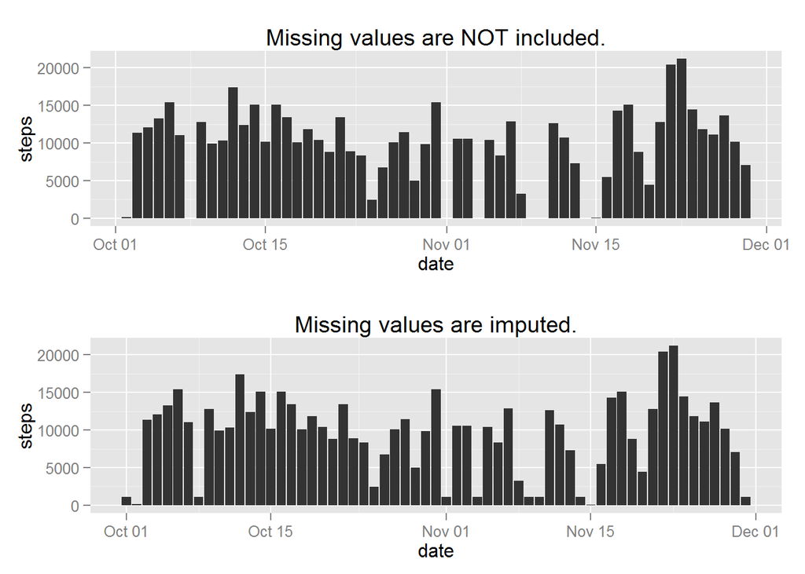

```r
gSD <- ggplot(DF, aes(x = date, y = steps)) + stat_summary(fun.y="sum", geom="bar") + ggtitle("Missing values are NOT included.")
gSDim <- ggplot(DFim, aes(x = date, y = steps)) + stat_summary(fun.y="sum", geom="bar") + ggtitle("Missing values are imputed.")
require(gridExtra)
grid.arrange(gSD, gSDim, ncol=1)
```

And now let us take a look on the distribution - let us make a histogram

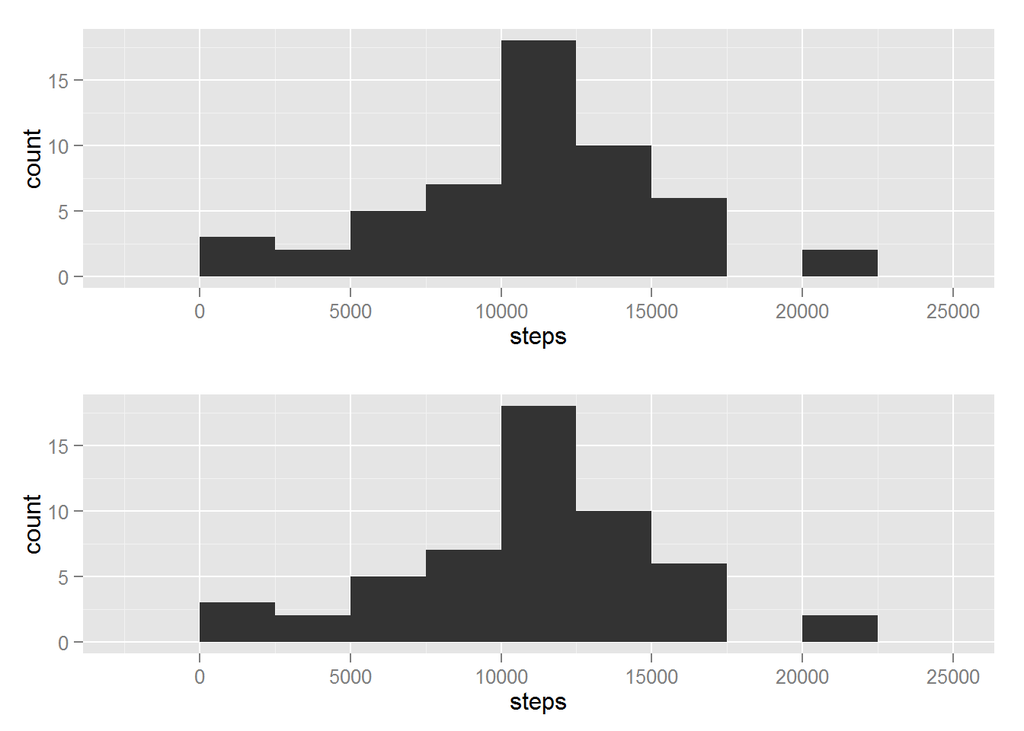

```r
forHist <- aggregate(steps ~ date, FUN=sum, data=DF)
gH <- ggplot(forHist, aes(x=steps)) + geom_histogram(binwidth=2500)

forHistIm <- aggregate(steps ~ date, FUN=sum, data=DFim)
gHim <- ggplot(forHist, aes(x=steps)) + geom_histogram(binwidth=2500)

require(gridExtra)
grid.arrange(gH, gHim, ncol=1)
```

Les us also compare mean and median of total number of steps taken per day.

```r
sBd_Im <- aggregate(DFim$steps, by=list(DFim$date), FUN=sum)
MeanMedian_Im <- c( mean(sBd_Im$x, na.rm=TRUE), median(sBd_Im$x, na.rm=TRUE) )
names(MeanMedian_Im) <- c("mean", "median")
print(MeanMedian) # missing data are NOT included
```

```
##   mean median
##  10766  10765
```

```r
print(MeanMedian_Im) # missing data are imputed
```

```
##   mean median
##   9504  10395
```

We see there is some difference between values and dependencies obtained with and without imputation. Average value decreases more noticeable comparing to median value.

## Are there differences in activity patterns between weekdays and weekends?

Now, let us consider if there is a difference between activity during weekdays and weekends.

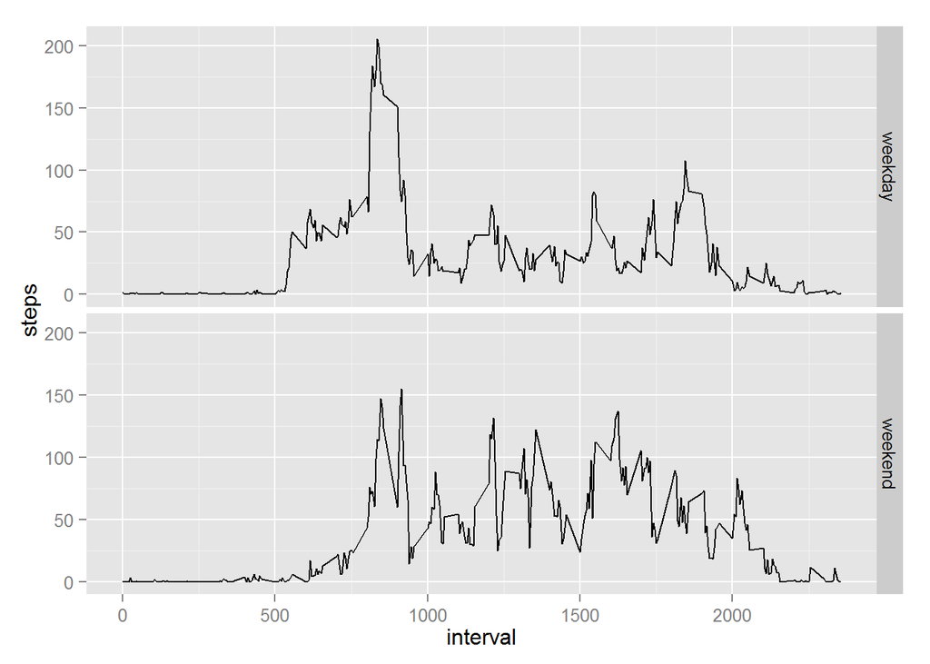

```r
wd <- weekdays(DF$date, abbreviate=TRUE)

DFim$day <- "weekday"
DFim[wd == "Sun" | wd == "Sat", "day"] <- "weekend"
DFim <- transform(DFim, day <- as.factor(day))

gDay <- ggplot(DFim) +
    stat_summary(aes(interval, steps), fun.y="mean", geom="line") +
    facet_grid(day ~ .)
print(gDay)
```

As we see people tend to shift the activity to daytime during weekends.

This concludes this assignment.